# Trait Plasticity based on climate transfer distance

Anoob Prakash

03/03/2021

# Methods

**family BLUP model**  
- Mixed effect model run to get the family level blups for use in the MCMC run.  
- Garden is set as the fixed effect.  
- Family and mBed (5 beds x 3 sites) set as random effect.  
- Height growth for a season is used as the fitness proxy to compare the adaptive nature of trait plasticity.  
- This helps in explaining whether the change in plasticity for a trait (positive/negative) is adaptive (top right of the plot) or maladaptive (bottom left of the plot).

```
# Creating mBed
fitness <- fitness %>% unite(mBed, Garden, Bed, sep = "_", remove = FALSE)

# lmer model for family blup
fitness_mod <- lmer(Growth ~ Garden + (1|mBed) + (1|Family), fitness)

# extract the blups for the family from the model
fitness_blup <- ranef(fitness_mod)
fitness_blup <- fitness_blup$Family
fitness_blup <- cbind(Family=rownames(fitness_blup),fitness_blup)
rownames(fitness_blup) <- NULL
names(fitness_blup)[2] <- "fitness"
```

**Trait plasticity (as described in the paper)**  
To estimate phenotypic plasticity for each trait, we ran LMMs (Model IV, Table S1) that included the fixed effect of garden climate (gPC1, based on each garden’s eigenvector score along PC1 of the climate PCA for the year of measurement), and random effects of Bed (1|Bed) and Family with random intercepts and slopes (gPC1|Family). We used the ‘coef()’ function to extract the random slopes for each Family with gPC1, which provides a measure of plasticity to garden climate (Arnold et al. 2019). To test if the magnitude of plasticity reflected differences due to source climate variability, we modeled the absolute value of plasticity as a function of source climate (sPC1), with a random effect of Population (Model V, Table S1).

```r
# setwd("Z:/Anoob/MCMCglmm")

suppressPackageStartupMessages({
# packages
require(MCMCglmm)
require(lmerTest)
require(dplyr)
require(tidyr)
require(data.table)
require(ggplot2)
require(cowplot)
require(plyr)
})

# data
budset_2019 <- read.csv("./trait_data/BudSet_2019.csv")
budset_2020 <- read.csv("./trait_data/BudSet_2020.csv")
budbreak_2020 <- read.csv("./trait_data/BudBreak_2020_cGDD.csv")
heightGrowth_2019 <- read.csv("./trait_data/Growth_2019.csv")
heightGrowth_2020 <- read.csv("./trait_data/Growth_2020.csv")
# Plasticity <- read.csv("./trait_data/Plasticity.csv")
Meta <- read.table("./Exome/RS_Exome_metadata.txt", sep="\t",header=T)

PC_scores <- read.csv("./trait_data/PCA/PCA_score.csv", header=T)
PC_scores <- PC_scores[!is.na(PC_scores$Family),]

# meta data and PC

colnames(Meta)[colnames(Meta)=="Pop"] <- "Population"
Meta$Region <- as.factor(Meta$Region)
Meta$Region <- mapvalues(Meta$Region, from = c("C", "M", "E"), to = c("Core", "Margin", "Edge"));Meta$Region <- factor(Meta$Region,levels = c("Core", "Margin", "Edge"))


Meta <- merge(x=Meta,
                     y=PC_scores[,-c(1,2,3,5,17)],
                     by.x="Family",
                     by.y="Family")

Meta <- Meta[,c("Population","Family","Region","Latitude","Longitude","Elevation","PC1","PC2","PC3","PC4","PC5","PC6",
                "PC7","PC8","PC9","PC10","PC11")]
```

# Garden climate

**Garden climate**

```r
Garden_clim <- read.table("./ClimateNA/climNA_gardens_2019-20.txt", header=T)
Garden_clim
```

```
##   garden year MSP DD_0  DD5 DD18 PAS eFFP RH   TD CMD  MAR  EXT       PET
## 1     MD 2019 469  341 2649  368  94  297 66 25.4 212 15.2 36.4  866.3545
## 2     MD 2020 492  224 2548  362  44  299 67 23.7 131 14.8 36.4  872.7068
## 3     NC 2019 478   55 3873  803   5  324 64 20.4 277 17.1 37.7 1147.0480
## 4     NC 2020 723   52 3747  698   4  321 66 20.9 166 16.2 37.8 1094.4220
## 5     VT 2019 471  678 2451  407 172  293 67 31.9 147 13.9 39.6  746.0178
## 6     VT 2020 403  385 2633  483  74  294 67 28.8 226 14.2 38.9  793.8243
```

```r
selVars1 <- c('DD_0','DD18','MAR','PAS','MSP','RH','EXT','CMD','TD','eFFP','PET')
colnames(Garden_clim)[1] <- "Garden"
colnames(Garden_clim)[2] <- "Year"
```

```r
# create ID for garden means
# garden_identity <- Garden_climateNA1[,1]

# create ID for garden
garden_identity <- Garden_clim[,1:2]

# selected clim of gardens
data_p1 <- Garden_clim[,selVars1]
```

```r
garden_id <- garden_identity

colnames(garden_id)[1] <- "Garden"
colnames(garden_id)[2] <- "Year"

data_pca <- prcomp(Garden_clim[,-c(1:5)],scale. = T)

# Extract PC axes for plotting
PCAvalues <- data.frame(Garden = Garden_clim$Garden, Year = Garden_clim$Year,
                        data_pca$x)
PCAvalues$Year <- as.factor(PCAvalues$Year)

# Extract loadings of the variables
PCAloadings <- data.frame(Variables = rownames(data_pca$rotation), data_pca$rotation)

# write.csv(PCAvalues, row.names = F, "./trait_data/PCA/PCA_garden_score.csv")
# write.csv(PCAloadings, row.names = F, "./trait_data/PCA/PCA_garden_loadings.csv")

PCAvalues_mod <- PCAvalues
PCAvalues_mod$Garden[PCAvalues_mod$Garden=="VT"] <- "Vermont"
PCAvalues_mod$Garden[PCAvalues_mod$Garden=="MD"] <- "Maryland"
PCAvalues_mod$Garden[PCAvalues_mod$Garden=="NC"] <- "North_Carolina"
```

# Trait plasticity

## Bud break 2020

- cGDD

```r
budbreak_2020 <- merge(x=budbreak_2020,y=PCAvalues_mod[PCAvalues_mod$Year=="2020",], all.x=TRUE)
budbreak_2020$mBed <- paste0(budbreak_2020$Garden,"_",budbreak_2020$Bed)

#plasticity model
budbreak_PC1_mod <- lmer(data = budbreak_2020, na.action = na.omit,
                          cGDD ~ PC1  + (1|mBed) + (PC1|Family))
summary(budbreak_PC1_mod)
```

```
## Linear mixed model fit by REML. t-tests use Satterthwaite's method [
## lmerModLmerTest]
## Formula: cGDD ~ PC1 + (1 | mBed) + (PC1 | Family)
##    Data: budbreak_2020
##
## REML criterion at convergence: 47653.9
##
## Scaled residuals:
##     Min      1Q  Median      3Q     Max
## -8.6484 -0.5404  0.0786  0.6205  4.0111
##
## Random effects:
##  Groups   Name        Variance Std.Dev. Corr
##  Family   (Intercept)  305.24  17.471
##           PC1           34.53   5.876   -0.97
##  mBed     (Intercept) 1081.09  32.880
##  Residual             1144.54  33.831
## Number of obs: 4757, groups:  Family, 334; mBed, 15
##
## Fixed effects:
##             Estimate Std. Error      df t value Pr(>|t|)
## (Intercept)  643.013      8.570  13.308  75.026  < 2e-16 ***
## PC1          -27.920      5.402  13.073  -5.169 0.000177 ***
## ---
## Signif. codes:  0 '***' 0.001 '**' 0.01 '*' 0.05 '.' 0.1 ' ' 1
##
## Correlation of Fixed Effects:
##     (Intr)
## PC1 -0.061
## optimizer (nloptwrap) convergence code: 0 (OK)
## Model failed to converge with max|grad| = 0.00453019 (tol = 0.002, component 1)
```

```r
budbreak_PC1 <- ranef(budbreak_PC1_mod)
budbreak_PC1 <- budbreak_PC1$Family
budbreak_PC1 <- cbind(Family=rownames(budbreak_PC1),budbreak_PC1)
rownames(budbreak_PC1) <- NULL

budbreak_PC1$Family <- as.factor(budbreak_PC1$Family)
colnames(budbreak_PC1)[colnames(budbreak_PC1)=="PC1"] <- "BudBreak_2020"
budbreak_PC1 <- budbreak_PC1[,-2]
head(budbreak_PC1)
```

```
##   Family BudBreak_2020
## 1  AB_05    -5.8545602
## 2  AB_08     2.5435443
## 3  AB_12    -3.8914145
## 4  AB_16    -4.1721421
## 5  AB_18    -0.8298989
## 6 ALB_01    -3.2717690
```

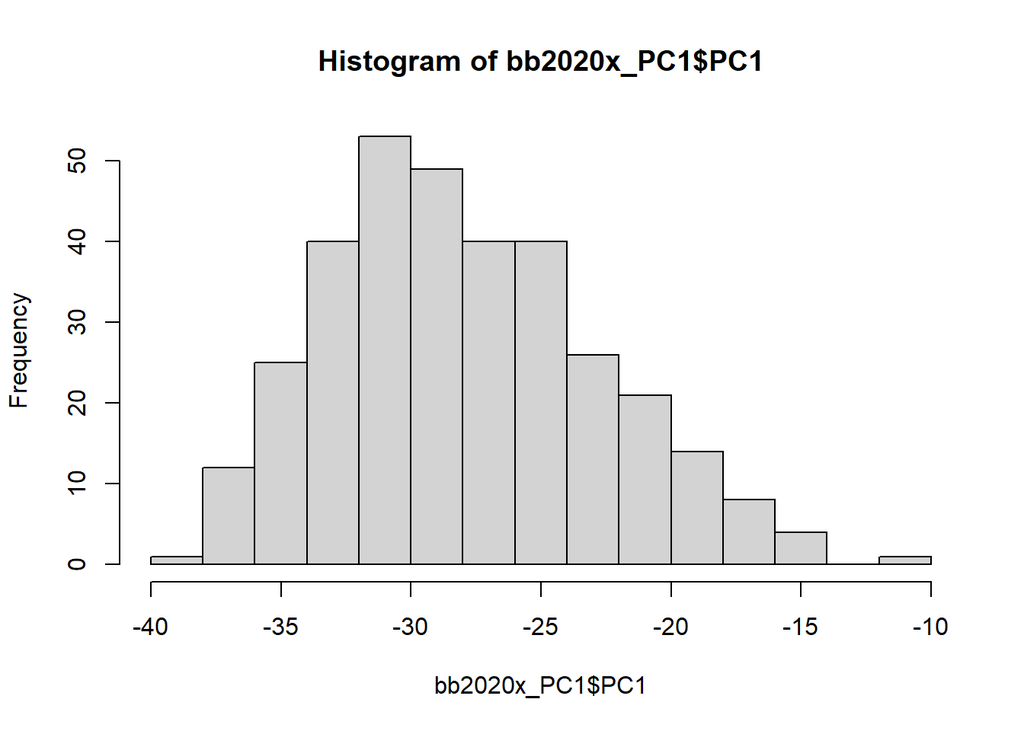

```r
# converting the negative values to absolute values to make plasticity values comparable across the traits

bb2020x_PC1 <- coef(budbreak_PC1_mod)
# hist(testx_PC1$PC1)
bb2020x_PC1 <- bb2020x_PC1$Family
bb2020x_PC1 <- cbind(Family=rownames(bb2020x_PC1),bb2020x_PC1)
rownames(bb2020x_PC1) <- NULL
bb2020x_PC1$abs <- abs(bb2020x_PC1$PC1)
hist(bb2020x_PC1$PC1)
```

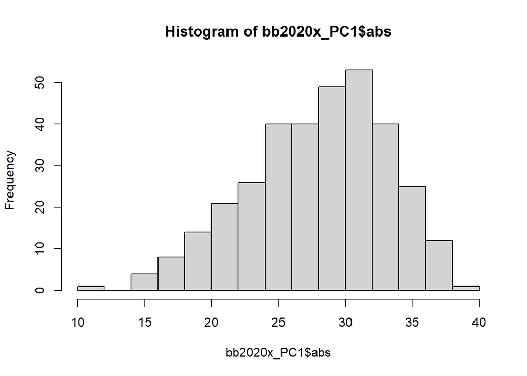

```r
hist(bb2020x_PC1$abs)
```

```r
bb2020x_PC1 <- bb2020x_PC1[,-2]
colnames(bb2020x_PC1)[3] <- "BudBreak_cGDD"
bb2020x_PC1 <- bb2020x_PC1[,-2]
```

- DOY

```r
budbreak_2020_DOY <- merge(x=budbreak_2020,y=PCAvalues_mod[PCAvalues_mod$Year=="2020",], all.x=TRUE)
budbreak_2020_DOY$mBed <- paste0(budbreak_2020_DOY$Garden,"_",budbreak_2020_DOY$Bed)

#plasticity model
budbreak_DOY_PC1_mod <- lmer(data = budbreak_2020_DOY, na.action = na.omit,
                          BudBreak ~ PC1  + (1|mBed) + (PC1|Family))

summary(budbreak_DOY_PC1_mod)
```

```
## Linear mixed model fit by REML. t-tests use Satterthwaite's method [
## lmerModLmerTest]
## Formula: BudBreak ~ PC1 + (1 | mBed) + (PC1 | Family)
##    Data: budbreak_2020_DOY
##
## REML criterion at convergence: 30004.6
##
## Scaled residuals:
##     Min      1Q  Median      3Q     Max
## -9.9704 -0.5442  0.0633  0.6057  4.0191
##
## Random effects:
##  Groups   Name        Variance Std.Dev. Corr
##  Family   (Intercept)  7.5674  2.7509
##           PC1          0.5274  0.7262   -0.95
##  mBed     (Intercept)  0.9968  0.9984
##  Residual             28.3259  5.3222
## Number of obs: 4757, groups:  Family, 334; mBed, 15
##
## Fixed effects:
##             Estimate Std. Error       df t value Pr(>|t|)
## (Intercept) 130.7792     0.3089  22.3288  423.31   <2e-16 ***
## PC1           8.2513     0.1754  14.5242   47.03   <2e-16 ***
## ---
## Signif. codes:  0 '***' 0.001 '**' 0.01 '*' 0.05 '.' 0.1 ' ' 1
##
## Correlation of Fixed Effects:
##     (Intr)
## PC1 -0.155
```

```r
budbreak_DOY_PC1 <- ranef(budbreak_DOY_PC1_mod)
budbreak_DOY_PC1 <- budbreak_DOY_PC1$Family
budbreak_DOY_PC1 <- cbind(Family=rownames(budbreak_DOY_PC1),budbreak_DOY_PC1)
rownames(budbreak_DOY_PC1) <- NULL

budbreak_DOY_PC1$Family <- as.factor(budbreak_DOY_PC1$Family)
colnames(budbreak_DOY_PC1)[colnames(budbreak_DOY_PC1)=="PC1"] <- "BudBreak_2020_DOY"
budbreak_DOY_PC1 <- budbreak_DOY_PC1[,-2]
head(budbreak_DOY_PC1)
```

```
##   Family BudBreak_2020_DOY
## 1  AB_05        -0.6581685
## 2  AB_08         0.2415947
## 3  AB_12        -0.4483200
## 4  AB_16        -0.4263305
## 5  AB_18        -0.1692816
## 6 ALB_01        -0.3407461
```

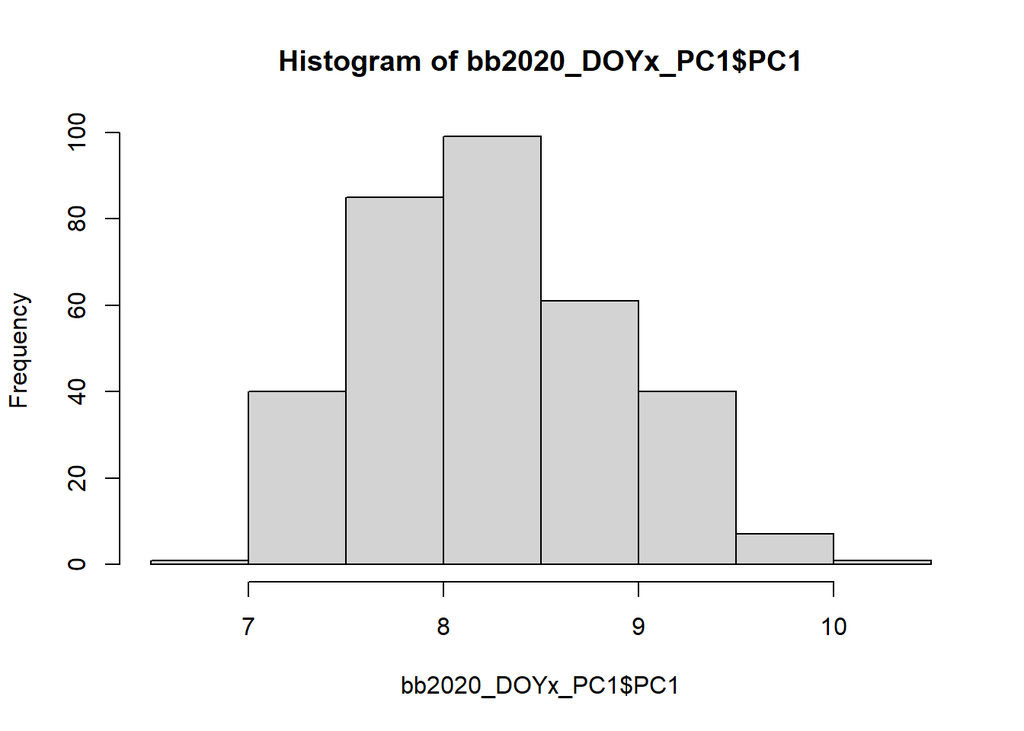

```r
# converting the negative values to absolute values to make plasticity values comparable across the traits

bb2020_DOYx_PC1 <- coef(budbreak_DOY_PC1_mod)
# hist(testx_PC1$PC1)
bb2020_DOYx_PC1 <- bb2020_DOYx_PC1$Family
bb2020_DOYx_PC1 <- cbind(Family=rownames(bb2020_DOYx_PC1),bb2020_DOYx_PC1)
rownames(bb2020_DOYx_PC1) <- NULL
bb2020_DOYx_PC1$abs <- abs(bb2020_DOYx_PC1$PC1)
hist(bb2020_DOYx_PC1$PC1)
```

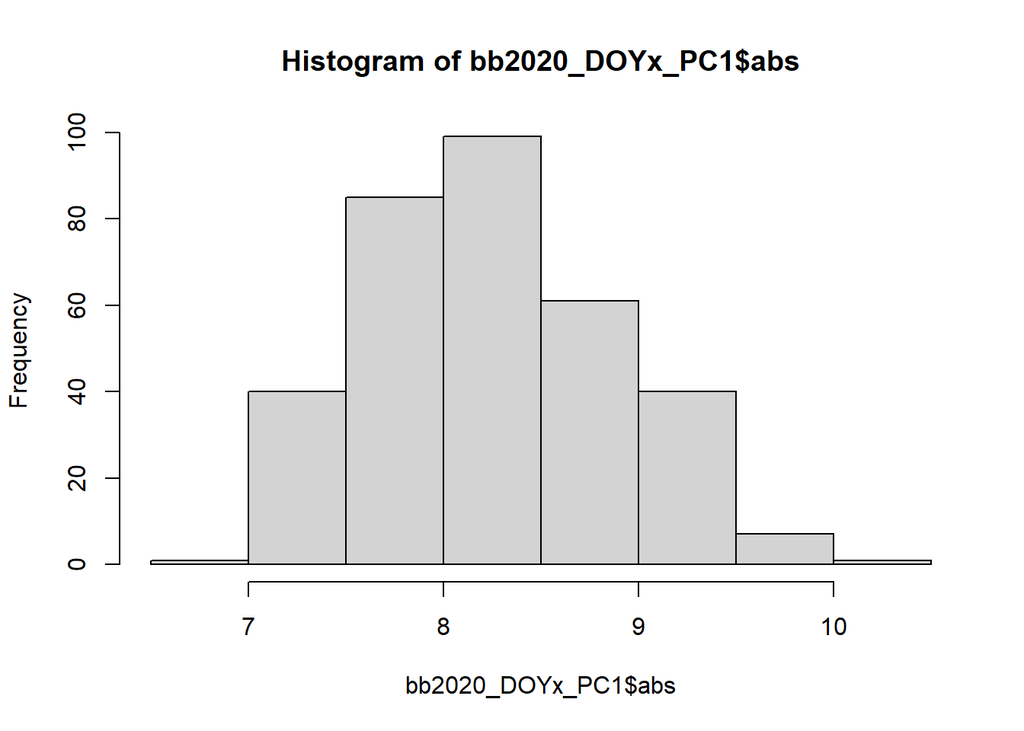

```r
hist(bb2020_DOYx_PC1$abs)
```

```r
bb2020_DOYx_PC1 <- bb2020_DOYx_PC1[,-2]
colnames(bb2020_DOYx_PC1)[3] <- "BudBreak_DOY"
bb2020_DOYx_PC1 <- bb2020_DOYx_PC1[,-2]
```

## Bud set 2019

```r
budset_2019 <- merge(x=budset_2019,y=PCAvalues_mod[PCAvalues_mod$Year=="2019",], all.x=TRUE)
budset_2019$mBed <- paste0(budset_2019$Garden,"_",budset_2019$Bed)

# plasticity model
budset_2019_PC1_mod <- lmer(data = budset_2019, na.action = na.omit,
                          BudSet ~ PC1  + (1|mBed) + (PC1|Family))

summary(budset_2019_PC1_mod)
```

```
## Linear mixed model fit by REML. t-tests use Satterthwaite's method [
## lmerModLmerTest]
## Formula: BudSet ~ PC1 + (1 | mBed) + (PC1 | Family)
##    Data: budset_2019
##
## REML criterion at convergence: 44149.9
##
## Scaled residuals:
##     Min      1Q  Median      3Q     Max
## -3.0560 -0.7264  0.2055  0.7190  2.3287
##
## Random effects:
##  Groups   Name        Variance Std.Dev. Corr
##  Family   (Intercept) 107.581  10.372
##           PC1           2.326   1.525   -0.06
##  mBed     (Intercept)  20.846   4.566
##  Residual             645.778  25.412
## Number of obs: 4685, groups:  Family, 334; mBed, 15
##
## Fixed effects:
##             Estimate Std. Error       df t value Pr(>|t|)
## (Intercept) 256.4645     1.3623  19.1099 188.265  < 2e-16 ***
## PC1           3.1744     0.4383  14.2106   7.243 3.92e-06 ***
## ---
## Signif. codes:  0 '***' 0.001 '**' 0.01 '*' 0.05 '.' 0.1 ' ' 1
##
## Correlation of Fixed Effects:
##     (Intr)
## PC1 0.016
```

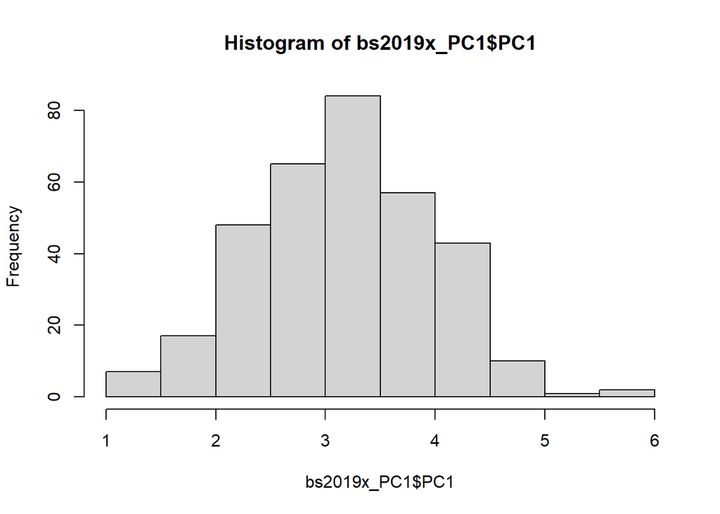

```r
budset_2019_PC1 <- ranef(budset_2019_PC1_mod)
budset_2019_PC1 <- budset_2019_PC1$Family
budset_2019_PC1 <- cbind(Family=rownames(budset_2019_PC1),budset_2019_PC1)
rownames(budset_2019_PC1) <- NULL

budset_2019_PC1$Family <- as.factor(budset_2019_PC1$Family)
colnames(budset_2019_PC1)[colnames(budset_2019_PC1)=="PC1"] <- "BudSet_2019"
budset_2019_PC1 <- budset_2019_PC1[,-2]

bs2019x_PC1 <- coef(budset_2019_PC1_mod)
# hist(testx_PC1$PC1)
bs2019x_PC1 <- bs2019x_PC1$Family
bs2019x_PC1 <- cbind(Family=rownames(bs2019x_PC1),bs2019x_PC1)
rownames(bs2019x_PC1) <- NULL
bs2019x_PC1$abs <- abs(bs2019x_PC1$PC1)
hist(bs2019x_PC1$PC1)
```

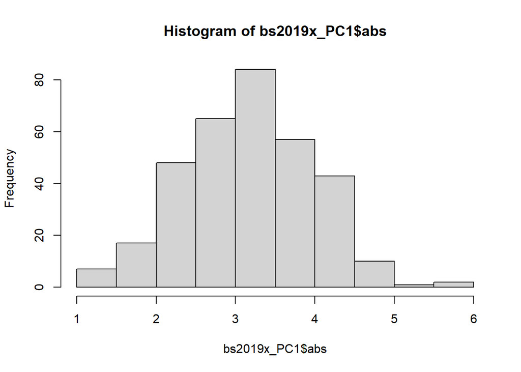

```r
hist(bs2019x_PC1$abs)
```

```r
bs2019x_PC1 <- bs2019x_PC1[,-c(2:3)]
colnames(bs2019x_PC1)[2] <- "BudSet_2019"
```

## Bud set 2020

```r
budset_2020 <- merge(x=budset_2020,y=PCAvalues_mod[PCAvalues_mod$Year=="2020",], all.x=TRUE)
budset_2020$mBed <- paste0(budset_2020$Garden,"_",budset_2020$Bed)



# plasticity model
budset_2020_PC1_mod <- lmer(data = budset_2020, na.action = na.omit,
                          BudSet ~ PC1  + (1|mBed) + (PC1|Family))

summary(budset_2020_PC1_mod)
```

```
## Linear mixed model fit by REML. t-tests use Satterthwaite's method [
## lmerModLmerTest]
## Formula: BudSet ~ PC1 + (1 | mBed) + (PC1 | Family)
##    Data: budset_2020
##
## REML criterion at convergence: 37189.1
##
## Scaled residuals:
##     Min      1Q  Median      3Q     Max
## -3.1937 -0.6040 -0.2718  0.5537  3.2311
##
## Random effects:
##  Groups   Name        Variance Std.Dev. Corr
##  Family   (Intercept)  27.376   5.232
##           PC1           1.165   1.080   0.14
##  mBed     (Intercept) 102.524  10.125
##  Residual             319.734  17.881
## Number of obs: 4282, groups:  Family, 334; mBed, 15
##
## Fixed effects:
##             Estimate Std. Error      df t value Pr(>|t|)
## (Intercept)  218.488      2.649  13.328  82.489  < 2e-16 ***
## PC1            5.832      1.668  13.061   3.495  0.00392 **
## ---
## Signif. codes:  0 '***' 0.001 '**' 0.01 '*' 0.05 '.' 0.1 ' ' 1
##
## Correlation of Fixed Effects:
##     (Intr)
## PC1 -0.055
```

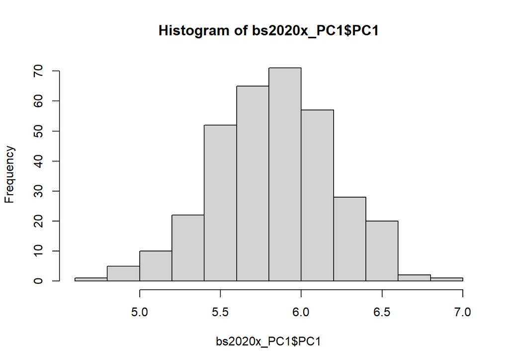

```r
budset_2020_PC1 <- ranef(budset_2020_PC1_mod)
budset_2020_PC1 <- budset_2020_PC1$Family
budset_2020_PC1 <- cbind(Family=rownames(budset_2020_PC1),budset_2020_PC1)
rownames(budset_2020_PC1) <- NULL

budset_2020_PC1$Family <- as.factor(budset_2020_PC1$Family)
colnames(budset_2020_PC1)[colnames(budset_2020_PC1)=="PC1"] <- "BudSet_2020"
budset_2020_PC1 <- budset_2020_PC1[,-2]

bs2020x_PC1 <- coef(budset_2020_PC1_mod)
# hist(testx_PC1$PC1)
bs2020x_PC1 <- bs2020x_PC1$Family
bs2020x_PC1 <- cbind(Family=rownames(bs2020x_PC1),bs2020x_PC1)
rownames(bs2020x_PC1) <- NULL
bs2020x_PC1$abs <- abs(bs2020x_PC1$PC1)
hist(bs2020x_PC1$PC1)
```

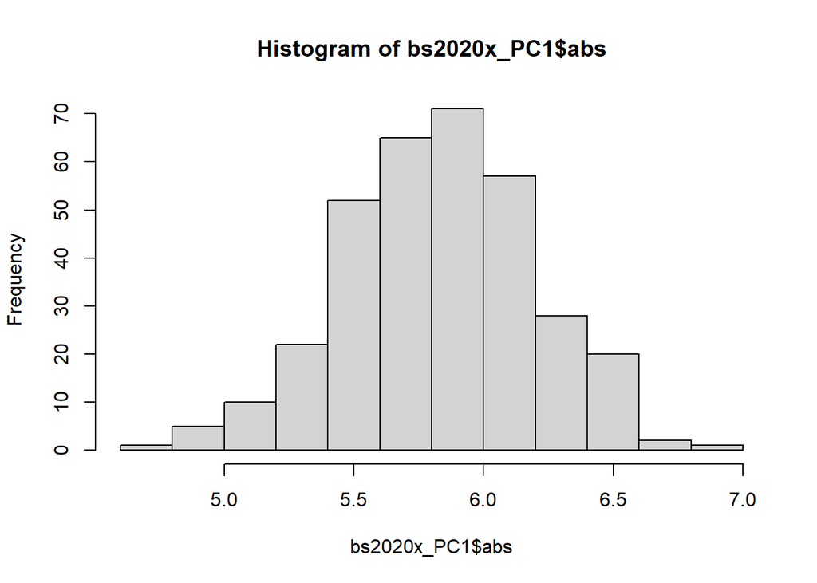

```r
hist(bs2020x_PC1$abs)
```

```r
bs2020x_PC1 <- bs2020x_PC1[,-c(2:3)]
colnames(bs2020x_PC1)[2] <- "BudSet_2020"
```

## Growth 2019

```r
growth_2019 <- merge(x=heightGrowth_2019,y=PCAvalues_mod[PCAvalues_mod$Year=="2019",], all.x=TRUE)
growth_2019$mBed <- paste0(growth_2019$Garden,"_",growth_2019$Bed)



# plasticity model
growth_2019_PC1_mod <- lmer(data = growth_2019, na.action = na.omit,
                          Growth ~ PC1  + (1|mBed) + (PC1|Family))
```

```
## boundary (singular) fit: see ?isSingular
```

```r
summary(growth_2019_PC1_mod)
```

```
## Linear mixed model fit by REML. t-tests use Satterthwaite's method [
## lmerModLmerTest]
## Formula: Growth ~ PC1 + (1 | mBed) + (PC1 | Family)
##    Data: growth_2019
##
## REML criterion at convergence: 30471
##
## Scaled residuals:
##     Min      1Q  Median      3Q     Max
## -3.3461 -0.6843 -0.0734  0.5849  7.7062
##
## Random effects:
##  Groups   Name        Variance Std.Dev. Corr
##  Family   (Intercept)  7.36158 2.7132
##           PC1          0.01984 0.1408   1.00
##  mBed     (Intercept)  2.96525 1.7220
##  Residual             35.26015 5.9380
## Number of obs: 4681, groups:  Family, 334; mBed, 15
##
## Fixed effects:
##             Estimate Std. Error      df t value Pr(>|t|)
## (Intercept)  11.0434     0.4772 15.9954  23.142    1e-13 ***
## PC1           0.1561     0.1575 13.1595   0.991     0.34
## ---
## Signif. codes:  0 '***' 0.001 '**' 0.01 '*' 0.05 '.' 0.1 ' ' 1
##
## Correlation of Fixed Effects:
##     (Intr)
## PC1 0.041
## optimizer (nloptwrap) convergence code: 0 (OK)
## boundary (singular) fit: see ?isSingular
```

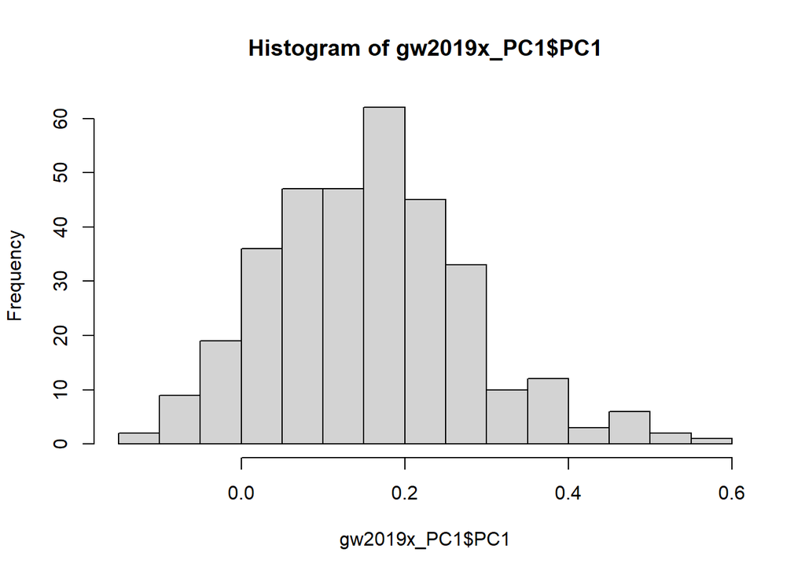

```r
# ranef
growth_2019_PC1 <- ranef(growth_2019_PC1_mod)
growth_2019_PC1 <- growth_2019_PC1$Family
growth_2019_PC1 <- cbind(Family=rownames(growth_2019_PC1),growth_2019_PC1)
rownames(growth_2019_PC1) <- NULL

growth_2019_PC1$Family <- as.factor(growth_2019_PC1$Family)
colnames(growth_2019_PC1)[colnames(growth_2019_PC1)=="PC1"] <- "Growth_2019"
growth_2019_PC1 <- growth_2019_PC1[,-2]

# coef
gw2019x_PC1 <- coef(growth_2019_PC1_mod)
gw2019x_PC1 <- gw2019x_PC1$Family
gw2019x_PC1 <- cbind(Family=rownames(gw2019x_PC1),gw2019x_PC1)
rownames(gw2019x_PC1) <- NULL
gw2019x_PC1$abs <- abs(gw2019x_PC1$PC1)
hist(gw2019x_PC1$PC1)
```

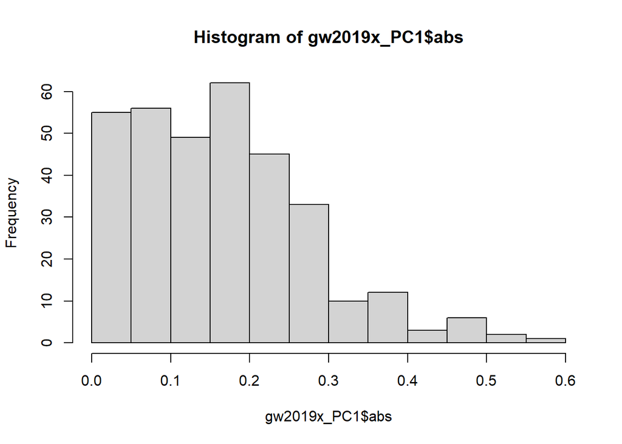

```r
hist(gw2019x_PC1$abs)
```

```r
gw2019x_PC1 <- gw2019x_PC1[,-c(2:3)]
colnames(gw2019x_PC1)[2] <- "Growth_2019"
```

## Growth 2020

```r
growth_2020 <- merge(x=heightGrowth_2020,y=PCAvalues_mod[PCAvalues_mod$Year=="2020",], all.x=TRUE)
growth_2020$mBed <- paste0(growth_2020$Garden,"_",growth_2020$Bed)



# plasticity model
growth_2020_PC1_mod <- lmer(data = growth_2020, na.action = na.omit,
                          Growth ~ PC1  + (1|mBed) + (PC1|Family))

summary(growth_2020_PC1_mod)
```

```
## Linear mixed model fit by REML. t-tests use Satterthwaite's method [
## lmerModLmerTest]
## Formula: Growth ~ PC1 + (1 | mBed) + (PC1 | Family)
##    Data: growth_2020
##
## REML criterion at convergence: 30330.7
##
## Scaled residuals:
##     Min      1Q  Median      3Q     Max
## -3.7661 -0.5754 -0.0754  0.4788  5.2978
##
## Random effects:
##  Groups   Name        Variance Std.Dev. Corr
##  Family   (Intercept) 11.0872  3.3297
##           PC1          0.1973  0.4442   -0.86
##  mBed     (Intercept)  1.7268  1.3141
##  Residual             45.6260  6.7547
## Number of obs: 4475, groups:  Family, 334; mBed, 15
##
## Fixed effects:
##             Estimate Std. Error      df t value Pr(>|t|)
## (Intercept)  16.2121     0.3989 20.5972  40.645  < 2e-16 ***
## PC1           0.8208     0.2257 13.2012   3.637  0.00294 **
## ---
## Signif. codes:  0 '***' 0.001 '**' 0.01 '*' 0.05 '.' 0.1 ' ' 1
##
## Correlation of Fixed Effects:
##     (Intr)
## PC1 -0.089
```

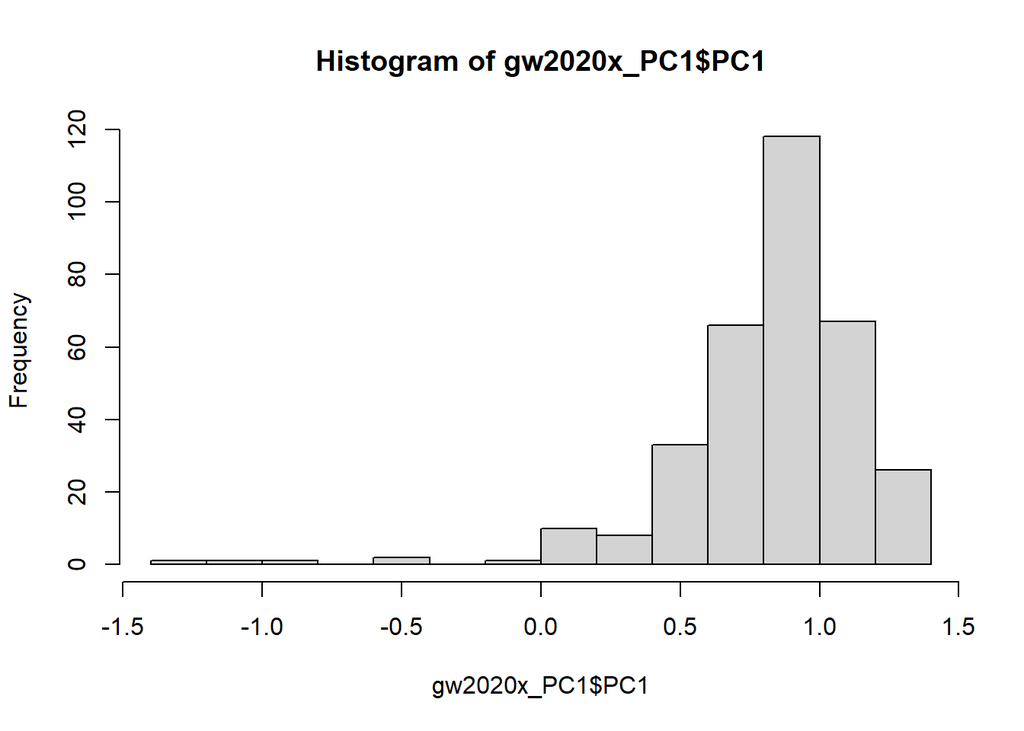

```r
growth_2020_PC1 <- ranef(growth_2020_PC1_mod)
growth_2020_PC1 <- growth_2020_PC1$Family
growth_2020_PC1 <- cbind(Family=rownames(growth_2020_PC1),growth_2020_PC1)
rownames(growth_2020_PC1) <- NULL

growth_2020_PC1$Family <- as.factor(growth_2020_PC1$Family)
colnames(growth_2020_PC1)[colnames(growth_2020_PC1)=="PC1"] <- "Growth_2020"
growth_2020_PC1 <- growth_2020_PC1[,-2]

gw2020x_PC1 <- coef(growth_2020_PC1_mod)
# hist(testx_PC1$PC1)
gw2020x_PC1 <- gw2020x_PC1$Family
gw2020x_PC1 <- cbind(Family=rownames(gw2020x_PC1),gw2020x_PC1)
rownames(gw2020x_PC1) <- NULL
gw2020x_PC1$abs <- abs(gw2020x_PC1$PC1)
hist(gw2020x_PC1$PC1)
```

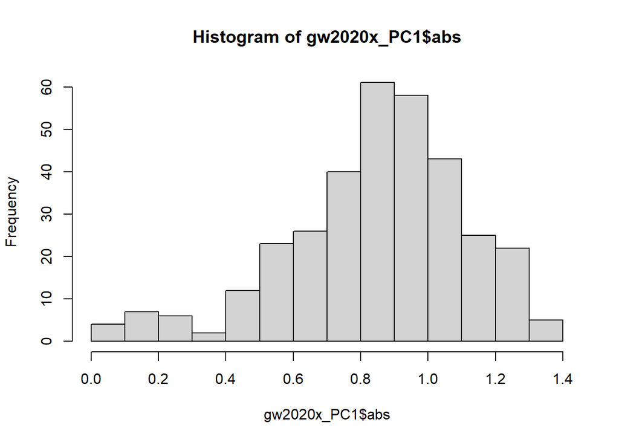

```r
hist(gw2020x_PC1$abs)
```

```r
gw2020x_PC1 <- gw2020x_PC1[,-c(2:3)]
colnames(gw2020x_PC1)[2] <- "Growth_2020"
```

# Plasticity

```r
Plasticity <- Reduce(function(x, y) merge(x, y, all=TRUE),
                     list(Meta,bb2020x_PC1,bb2020_DOYx_PC1,bs2019x_PC1,bs2020x_PC1,gw2019x_PC1,gw2020x_PC1))
Plasticity <- Plasticity[!is.na(Plasticity$BudBreak_cGDD),]

# write.csv(Plasticity, "./trait_data/Plasticity.csv")
```